# RECS ML

Author

Affiliation

Anthony Moubarak

MDI - EIDC

Published

Invalid Date

# 1 Abstract

Below is a structure of the project/Notebook:

- Introduction
- EDA
- Feature Selection:
  - LASSO Regression
  - Random Forest Best Feature Selector
- Machine Learning:
  - Subset 1 (LASSO subset):
    - OLS Regression
    - Random Forest Regressor
    - XGBoost Regressor
  - Subset 2 (Random Forest subset):
    - OLS Regression
    - Random Forest Regressor
    - XGBoost Regressor
  - PCA:
    - Models
  - Hyperparameter Tuning

# 2 Introduction

The United States’ energy landscape has undergone significant changes over the years, driven by advancements in technology and evolving consumer habits. Amidst these shifts, understanding and predicting household energy consumption become crucial for policymakers and energy providers to promote sustainability and optimize resource allocation.

In this project, we delve into the vast repository of data from the U.S. Energy Information Administration (EIA) Residential Energy Consumption Survey (RECS). By leveraging the power of machine learning and regression-based models, we aim to develop accurate predictors for annual energy consumption in households across the nation.

RECS, conducted since 1978, captures detailed information on homes’ characteristics, appliance usage, number of residents, and demographic insights.

```python
from sklearn.model_selection import train_test_split, cross_val_score, RandomizedSearchCV
from xgboost import XGBRegressor
from sklearn.decomposition import PCA
import xgboost as xgb
from sklearn.ensemble import RandomForestRegressor
from sklearn.metrics import r2_score
from sklearn.linear_model import LinearRegression
from sklearn.model_selection import train_test_split, cross_val_score
from sklearn.linear_model import LassoCV
import numpy as np
from scipy import stats
import random
from wordcloud import WordCloud, STOPWORDS
from sklearn.preprocessing import StandardScaler
import pandas as pd
import matplotlib.pyplot as plt
import seaborn as sns
import pandas as pd

df = pd.read_csv("Data/marged_recs.csv")
df
```

|  | DOEID | BA_climate | IECC_climate_code | UATYP10 | NWEIGHT_x | AIRCOND | COOLAPT | ACEQUIPM_PUB | ACEQUIPAGE | ACEQUIPAUXTYPE_PUB | ... | ALLELEC | ZBACKUP | ZELPAY | ZFOPAY | ZLPGPAY | ZNGPAY | ZOUTLET | ZPOWEROUT | ZWHYPOWEROUT | NWEIGHT |
| --- | --- | --- | --- | --- | --- | --- | --- | --- | --- | --- | --- | --- | --- | --- | --- | --- | --- | --- | --- | --- | --- |
| 0 | 102572 | Hot-Humid | 1A | C | 1444.115961 | 1 | -2 | 4 | 4 | 0 | ... | 0 | 0 | 0 | -2 | 0 | -2 | 0 | 1 | -2 | 1444.115961 |
| 1 | 108113 | Hot-Humid | 1A | C | 1567.888645 | 0 | -2 | -2 | -2 | -2 | ... | 1 | 0 | 0 | -2 | -2 | -2 | 0 | 0 | -2 | 1567.888645 |
| 2 | 101717 | Hot-Humid | 1A | C | 1332.524277 | 1 | -2 | 4 | 3 | 0 | ... | 0 | 1 | 0 | -2 | -2 | 0 | 1 | 1 | -2 | 1332.524277 |
| 3 | 117200 | Hot-Humid | 1A | C | 2007.834289 | 1 | -2 | 4 | 2 | 0 | ... | 1 | 0 | 0 | -2 | -2 | -2 | 0 | 0 | -2 | 2007.834289 |
| 4 | 117053 | Hot-Humid | 1A | C | 1366.567605 | 0 | -2 | -2 | -2 | -2 | ... | 0 | 0 | 0 | -2 | 0 | -2 | 0 | 0 | -2 | 1366.567605 |
| ... | ... | ... | ... | ... | ... | ... | ... | ... | ... | ... | ... | ... | ... | ... | ... | ... | ... | ... | ... | ... | ... |
| 18491 | 114155 | Subarctic | 8AK | U | 613.127293 | 1 | -2 | 4 | 3 | 0 | ... | 0 | 0 | 0 | 0 | -2 | -2 | 0 | 0 | -2 | 613.127293 |
| 18492 | 104782 | Subarctic | 8AK | U | 776.021704 | 0 | -2 | -2 | -2 | -2 | ... | 0 | 0 | 0 | -2 | -2 | 0 | 0 | 0 | -2 | 776.021704 |
| 18493 | 104907 | Subarctic | 8AK | U | 1028.339855 | 0 | -2 | -2 | -2 | -2 | ... | 0 | 0 | 1 | -2 | 1 | -2 | 0 | 1 | -2 | 1028.339855 |
| 18494 | 110200 | Subarctic | 8AK | U | 872.252048 | 0 | -2 | -2 | -2 | -2 | ... | 0 | 0 | 0 | 0 | -2 | -2 | 0 | 0 | -2 | 872.252048 |
| 18495 | 101975 | Subarctic | 8AK | U | 1088.905666 | 0 | -2 | -2 | -2 | -2 | ... | 0 | 0 | 0 | 0 | -2 | -2 | 0 | 0 | -2 | 1088.905666 |

18496 rows × 740 columns

For a detailed breakdown and explanation of every variable, visit https://view.officeapps.live.com/op/view.aspx?src=https%3A%2F%2Fwww.eia.gov%2Fconsumption%2Fresidential%2Fdata%2F2020%2Fxls%2FRECS%25202020%2520Codebook%2520for%2520Public%2520File%2520-%2520v4.xlsx&wdOrigin=BROWSELINK

```python
# Assuming 'df' is your DataFrame
# Get the data types of each column in the DataFrame
data_types = df.dtypes

# Initialize empty lists to store numeric and categorical column names
numeric_columns = []
categorical_columns = []

# Iterate through each column and categorize them
for column_name, data_type in data_types.iteritems():
    if pd.api.types.is_numeric_dtype(data_type):
        numeric_columns.append(column_name)
    else:
        categorical_columns.append(column_name)

# Print the result
print("Numeric columns:", numeric_columns)
print("Categorical columns:", categorical_columns)
```

```
Numeric columns: ['DOEID', 'NWEIGHT_x', 'AIRCOND', 'COOLAPT', 'ACEQUIPM_PUB', 'ACEQUIPAGE', 'ACEQUIPAUXTYPE_PUB', 'NUMDLHPAC', 'NUMWWAC', 'NUMPORTAC', 'BASECOOL', 'ATTCCOOL', 'GARGCOOL', 'NUMCFAN', 'NUMFLOORFAN', 'USECFAN', 'HOUSEFAN', 'ATTICFAN', 'DEHUMTYPE', 'NUMPORTDEHUM', 'USEDEHUM', 'ELCOOL', '…
Categorical columns: ['BA_climate', 'IECC_climate_code', 'UATYP10', 'REGIONC', 'DIVISION', 'state_postal', 'state_name']
```

# 3 EDA

### 3.0.1 Distribution of target variable

We start by analyzing the distribution of the target variable KWH.

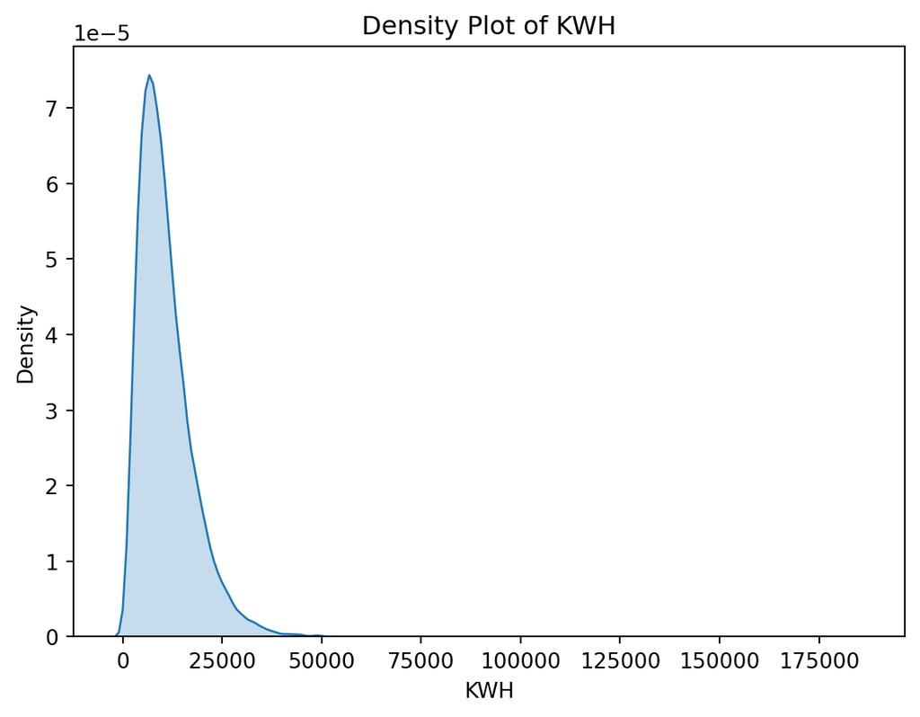

```python
sns.kdeplot(data=df['KWH'], shade=True)

# Optionally, you can adjust the plot settings for better visualization
plt.title('Density Plot of KWH')
plt.xlabel('KWH')
plt.ylabel('Density')

# Show the plot
plt.show()
```

The KWH is not normally distributed, as it has a long tail on the right (highly skewed positively), which is why applying a log transformation would make sense.

```python
df['log_KWH'] = np.log(df['KWH'])

numeric_columns.append('log_KWH')
```

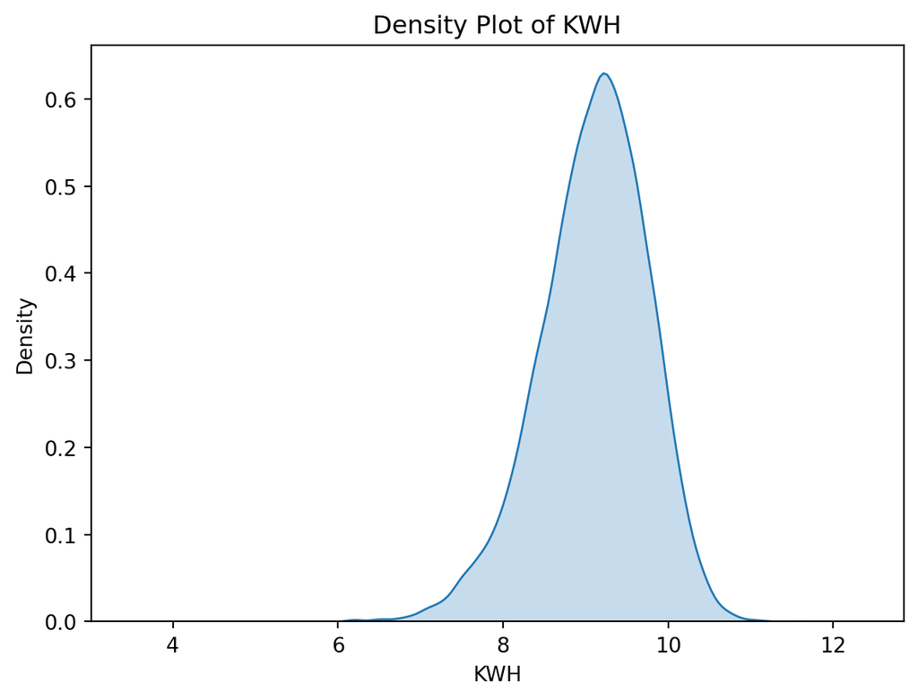

```python
# Assuming 'KWH' is the column name in the DataFrame 'df'
sns.kdeplot(data=df['log_KWH'], shade=True)

# Optionally, you can adjust the plot settings for better visualization
plt.title('Density Plot of KWH')
plt.xlabel('KWH')
plt.ylabel('Density')

# Show the plot
plt.show()
```

### 3.0.2 Correlations between numeric variables and KWH

Keeping numeric columns only

```python
numeric_df = df[numeric_columns]

numeric_df = numeric_df.drop(columns=['DOEID'])

numeric_df.head()
```

|  | NWEIGHT_x | AIRCOND | COOLAPT | ACEQUIPM_PUB | ACEQUIPAGE | ACEQUIPAUXTYPE_PUB | NUMDLHPAC | NUMWWAC | NUMPORTAC | BASECOOL | ... | ZBACKUP | ZELPAY | ZFOPAY | ZLPGPAY | ZNGPAY | ZOUTLET | ZPOWEROUT | ZWHYPOWEROUT | NWEIGHT | log_KWH |
| --- | --- | --- | --- | --- | --- | --- | --- | --- | --- | --- | --- | --- | --- | --- | --- | --- | --- | --- | --- | --- | --- |
| 0 | 1444.115961 | 1 | -2 | 4 | 4 | 0 | -2 | 2 | -2 | 0 | ... | 0 | 0 | -2 | 0 | -2 | 0 | 1 | -2 | 1444.115961 | 8.978345 |
| 1 | 1567.888645 | 0 | -2 | -2 | -2 | -2 | -2 | -2 | -2 | -2 | ... | 0 | 0 | -2 | -2 | -2 | 0 | 0 | -2 | 1567.888645 | 8.937779 |
| 2 | 1332.524277 | 1 | -2 | 4 | 3 | 0 | -2 | 4 | -2 | -2 | ... | 1 | 0 | -2 | -2 | 0 | 1 | 1 | -2 | 1332.524277 | 9.083577 |
| 3 | 2007.834289 | 1 | -2 | 4 | 2 | 0 | -2 | 3 | -2 | -2 | ... | 0 | 0 | -2 | -2 | -2 | 0 | 0 | -2 | 2007.834289 | 9.096925 |
| 4 | 1366.567605 | 0 | -2 | -2 | -2 | -2 | -2 | -2 | -2 | -2 | ... | 0 | 0 | -2 | 0 | -2 | 0 | 0 | -2 | 1366.567605 | 8.239863 |

5 rows × 733 columns

```python
# Compute the correlation between 'KWH' and all other columns
correlations = numeric_df.corr()['log_KWH']

# Filter the columns with correlation >= 0.4
columns_with_05_corr = correlations[correlations.abs() >= 0.5].index.tolist()

# Print the column names with correlation >= 0.4
print("Columns with correlation >= 0.5 with 'KWH':")
print(columns_with_05_corr)
```

```
Columns with correlation >= 0.5 with 'KWH':
['KWH', 'BTUEL', 'DOLLAREL', 'KWHCOL', 'KWHAHUCOL', 'KWHOTH', 'BTUELCOL', 'BTUELAHUCOL', 'BTUELOTH', 'DOLELOTH', 'TOTALDOL', 'log_KWH']
```

```python
# Compute the correlation between 'KWH' and all other columns
correlations = numeric_df.corr()['log_KWH']

# Filter the columns with correlation >= 0.4
columns_with_05_corr = correlations[correlations.abs() >= 0.5].index.tolist()

# Print the column names with correlation >= 0.4
print("Columns with correlation >= 0.5 with 'KWH':")
print(columns_with_05_corr)
```

```
Columns with correlation >= 0.5 with 'KWH':
['KWH', 'BTUEL', 'DOLLAREL', 'KWHCOL', 'KWHAHUCOL', 'KWHOTH', 'BTUELCOL', 'BTUELAHUCOL', 'BTUELOTH', 'DOLELOTH', 'TOTALDOL', 'log_KWH']
```

- BTUEL: Total electricity use, in thousand Btu (british thermal units).
- DOLLAREL: Total electricity cost, in dollars, 2020.
- KWHCOL: Calibrated electricity usage for space cooling.
- KWHAHUCOL: Calibrated electricity usage for furnace fans used for cooling.
- KWHOTH: Calibrated electricity usage for end uses other than space heating.
- BTUELCOL: Calibrated electricity usage for space cooling (central air conditioning, individual units, and evaporative coolers), in btu.
- BTUELAHUCOL: Calibrated electricity usage for furnace fans used for cooling, in thousand Btu.
- BTUELOTH: Calibrated electricity usage for end uses other than space heating, space cooling, water heating, and refrigerators, in thousand Btu.
- DOLELOTH: Calibrated electricity cost for end uses other than space heating, space cooling, water heating, and refrigerators.
- TOTALDOL: Total cost for space heating including electricity, natural gas, propane, and fuel oil, in dollars, 2020.

Most of the variables above are directly related to overall energy usage or are even the same metric but in a different unit (BTUEL for example), which is why relying solely on correlations to build a model will lead to inaccurate and/or skewed results.

### 3.0.3 Categorical Variable Analysis

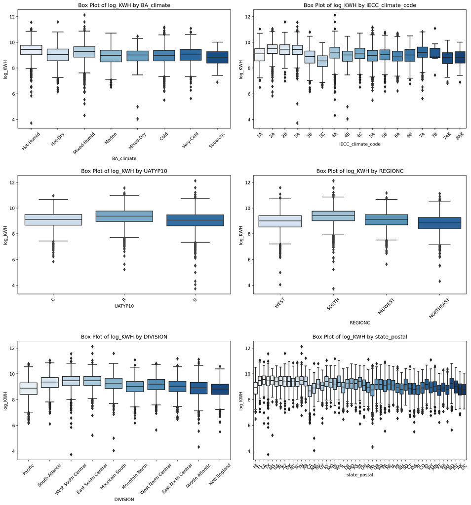

```python
# List of categorical columns to plot
categorical_columns = ['BA_climate', 'IECC_climate_code',
                       'UATYP10', 'REGIONC', 'DIVISION', 'state_postal', 'state_name']

# Create a 3x2 grid of subplots with an additional plot in the 4th row
fig, axes = plt.subplots(4, 2, figsize=(15, 20))

# Loop through each categorical column and create box plots
for i, column in enumerate(categorical_columns):
    row = i // 2
    col = i % 2
    sns.boxplot(x=column, y='log_KWH', data=df,
                ax=axes[row, col], palette='Blues')
    axes[row, col].set_title(f'Box Plot of log_KWH by {column}')
    axes[row, col].set_xlabel(column)
    axes[row, col].set_ylabel('log_KWH')
    axes[row, col].tick_params(axis='x', rotation=45)

# Remove the empty subplots in the 4th row
fig.delaxes(axes[3, 0])
fig.delaxes(axes[3, 1])

# Adjust layout to avoid overlapping titles and labels
fig.tight_layout()

plt.show()
```

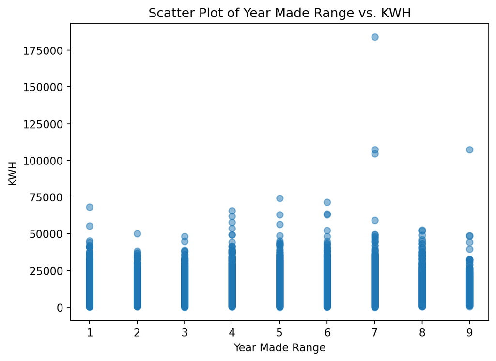

```python
# Extract the columns from the DataFrame
df['YEARMADERANGE'] = df['YEARMADERANGE'].astype('int')
year_made_range = df['YEARMADERANGE']
kwh = df['KWH']

# Create a scatter plot
# alpha controls the transparency of the points
plt.scatter(year_made_range, kwh, alpha=0.5)
plt.xlabel('Year Made Range')
plt.ylabel('KWH')
plt.title('Scatter Plot of Year Made Range vs. KWH')

# Set the desired order for xticks
plt.xticks([1, 2, 3, 4, 5, 6, 7, 8, 9])

# Show the plot
plt.show()
```

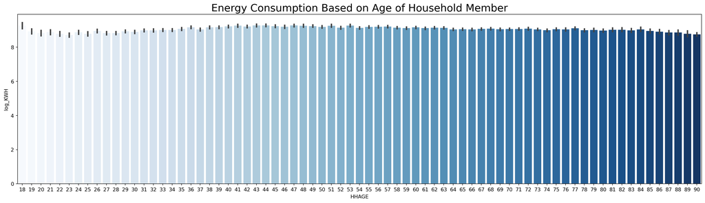

```python
plt.figure(figsize=(24, 6))
ax_age = sns.barplot(x="HHAGE", y="log_KWH", data=df, palette='Blues')
ax_age.set_title(
    "Energy Consumption Based on Age of Household Member", fontsize=20)
```

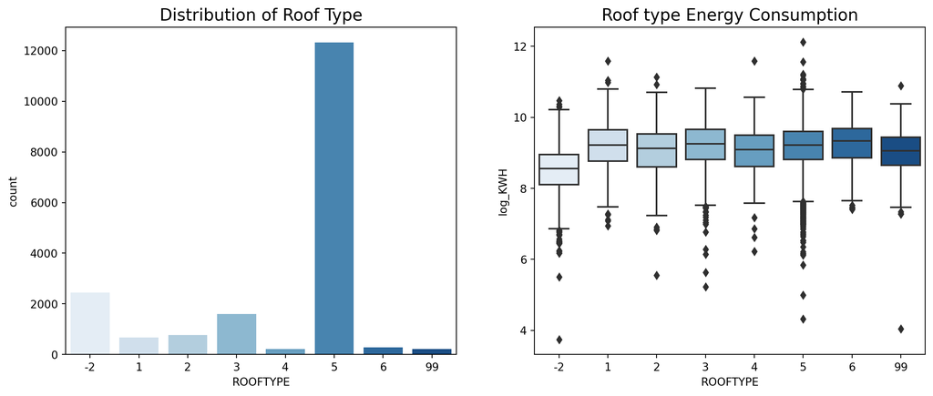

```python
plt.figure(figsize=(14, 6))
# I will explore the distribution of Roof type and roof type by log_KWH
plt.subplot(121)
ax_roof = sns.countplot(x='ROOFTYPE', data=df, palette='Blues')
ax_roof.set_title("Distribution of Roof Type", fontsize=15)


plt.subplot(122)
ax_roof = sns.boxplot(x="ROOFTYPE", y="log_KWH", data=df, palette='Blues')
ax_roof.set_title("Roof type Energy Consumption", fontsize=15)


plt.subplots_adjust(hspace=0.6, top=0.8)

plt.show()
```

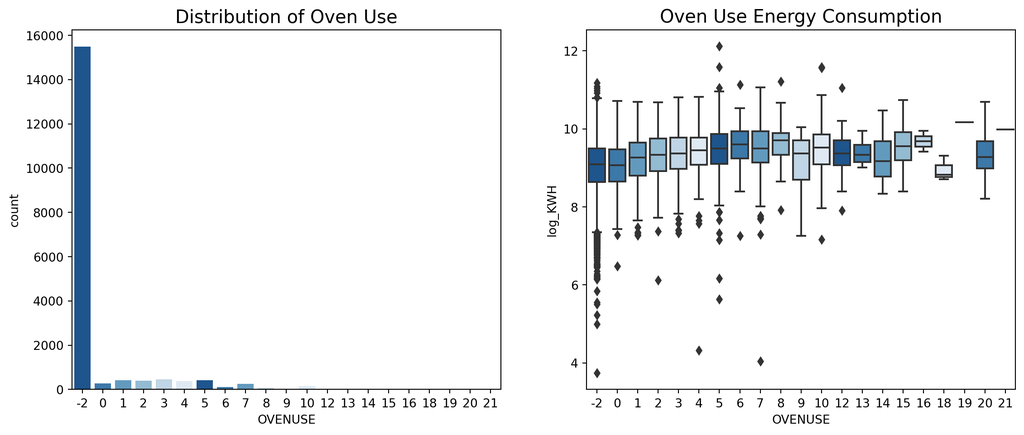

```python
plt.figure(figsize=(14, 6))

# I will explore the distribution of wall type and wall type by log_KWH
plt.subplot(121)
ax_oven = sns.countplot(x='OVENUSE', data=df, palette=list(
    reversed(sns.color_palette("Blues"))))
ax_oven.set_title("Distribution of Oven Use", fontsize=15)

plt.subplot(122)
ax_oven = sns.boxplot(x="OVENUSE", y="log_KWH", data=df,
                      palette=list(reversed(sns.color_palette("Blues"))))
ax_oven.set_title("Oven Use Energy Consumption", fontsize=15)

plt.subplots_adjust(hspace=0.6, top=0.8)

plt.show()
```

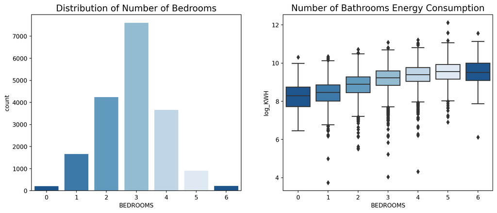

```python
plt.figure(figsize=(14, 6))
# I will explore the distribution of wall type and wall type by log_KWH
plt.subplot(121)
ax_bedroom = sns.countplot(x='BEDROOMS', data=df, palette=list(
    reversed(sns.color_palette("Blues"))))
ax_bedroom.set_title("Distribution of Number of Bedrooms", fontsize=15)


plt.subplot(122)
ax_bedroom = sns.boxplot(x="BEDROOMS", y="log_KWH", data=df, palette=list(
    reversed(sns.color_palette("Blues"))))
ax_bedroom.set_title("Number of Bathrooms Energy Consumption", fontsize=15)


plt.subplots_adjust(hspace=0.6, top=0.8)

plt.show()
```

# 4 Feature Selection

The Random Forest Best Feature selector leverages the strength of the Random Forest algorithm to identify the most influential predictors. By constructing multiple decision trees and considering the collective insights of each tree, this method efficiently assesses feature importance, enabling us to isolate the most significant variables that drive annual energy consumption in households. Its robustness to handle complex relationships and its ability to handle both numerical and categorical features make it an excellent approach for feature selection in high-dimensional datasets.

Similarly, LASSO (Least Absolute Shrinkage and Selection Operator) Regression is a technique to identify the most relevant predictors. It applies L1 regularization, which introduces a penalty term that encourages some coefficients to precisely zero. This results in a sparse model, automatically selecting the most influential variables while discarding less impactful ones. LASSO’s ability to simultaneously perform variable selection and regularization makes it an efficient and interpretable approach for high-dimensional datasets.

```python
categorical_columns = ['BA_climate', 'IECC_climate_code',
                       'UATYP10', 'REGIONC', 'DIVISION', 'state_postal', 'state_name']

df = df.drop(columns=['DOEID'])

# Define the categorical columns to be one-hot encoded
categorical_columns = ['BA_climate', 'IECC_climate_code',
                       'UATYP10', 'REGIONC', 'DIVISION', 'state_postal', 'state_name']

# Perform one-hot encoding
df_encoded = pd.get_dummies(df, columns=categorical_columns)

df_encoded.dropna(inplace=True)
```

Dropping some additional useless columns:

```python
modeled_variables = pd.read_csv("Data/end_use_model.csv")
useless_columns = modeled_variables.columns.values[1:].tolist()
main_array = useless_columns
# Convert the list of columns to drop and the DataFrame columns into sets
useless_columns_set = set(main_array)
df_columns_set = set(df_encoded.columns)

# Get the intersection of the set of columns in the DataFrame and the set of columns to drop
columns_to_drop = list(useless_columns_set.intersection(df_columns_set))

# Drop only the columns that are present in both DataFrame and the list
df_encoded.drop(columns=columns_to_drop, inplace=True)

columns_to_drop = [
    col for col in df_encoded.columns if col.startswith('NWEIGHT')]
df_encoded.drop(columns=columns_to_drop, inplace=True)
```

Next, a LASSO regression model should be ran to get a subset of features that lead to a good result.

```python
# Separate the target variable 'log_KWH' from the predictors
X = df_encoded.drop(columns=['log_KWH', 'KWH'])
y = df_encoded['log_KWH']

# Perform LASSO regression with cross-validation to find the best alpha
lasso_model = LassoCV(cv=5)
lasso_model.fit(X, y)

# Get the best alpha and selected features
best_alpha = lasso_model.alpha_
selected_features = X.columns[lasso_model.coef_ != 0]

# Subset the DataFrame with the selected features
df_best_features = df_encoded[selected_features]

# Print the best alpha and selected features
print("Best alpha:", best_alpha)
print("Selected features:", selected_features)
```

```
Best alpha: 0.3334986695858697
Selected features: Index(['HHAGE', 'TVONWE1', 'TVONWE2', 'TEMPGONE', 'TEMPHOMEAC', 'STATE_FIPS',
       'SQFTEST', 'TOTSQFT_EN', 'TOTHSQFT', 'TOTCSQFT', 'HDD65', 'CDD65',
       'HDD30YR_PUB', 'CDD30YR_PUB', 'EQUIPAUXTYPE', 'AMTMICRO',
       'OUTGRILLFUEL', 'WASHLOAD', 'DRYRUSE'],
      dtype='object')
```

```python
# Get the coefficients from the LASSO regression model
lasso_coefficients = pd.Series(lasso_model.coef_, index=X.columns)

# Filter out non-zero coefficients
selected_features_non_zero = lasso_coefficients[lasso_coefficients != 0]


# Sort the selected_features_non_zero Series in descending order of absolute values
selected_features_ranked = selected_features_non_zero.abs().sort_values(ascending=False)

# Print the ranked features/variables and their corresponding impact on log_KWH
print("Ranked Impact on log_KWH:")
print(selected_features_ranked)
```

```
Ranked Impact on log_KWH:
DRYRUSE         1.784441e-02
TVONWE2         8.581294e-03
OUTGRILLFUEL    3.064566e-03
WASHLOAD        2.754054e-03
TEMPGONE        2.660412e-03
STATE_FIPS      1.973976e-03
EQUIPAUXTYPE    1.300752e-03
TVONWE1         7.883682e-04
AMTMICRO        7.304686e-04
HHAGE           6.998048e-04
TEMPHOMEAC      5.332825e-04
CDD30YR_PUB     2.833219e-04
SQFTEST         1.985019e-04
CDD65           9.359580e-05
HDD30YR_PUB     6.958664e-05
TOTCSQFT        6.880410e-05
HDD65           6.006272e-05
TOTSQFT_EN      1.991966e-05
TOTHSQFT        5.138735e-07
dtype: float64
```

```python
# Assuming df_encoded is your DataFrame
X = df_encoded.drop(columns=['log_KWH', 'KWH'])
y = df_encoded['log_KWH']

# Initialize and train the Random Forest Regressor model
# You can adjust other hyperparameters as needed
rf_model = RandomForestRegressor(random_state=42)
rf_model.fit(X, y)
```

```
RandomForestRegressor(random_state=42)
```

```python
# Get the feature importances from the trained Random Forest model
feature_importances = rf_model.feature_importances_

# Create a DataFrame to store the feature importances along with their corresponding column names
feature_importances_df = pd.DataFrame(
    {'Feature': X.columns, 'Importance': feature_importances})

# Sort the DataFrame by importance in descending order to see the most important features
feature_importances_df.sort_values(
    by='Importance', ascending=False, inplace=True)

feature_importances_df['Feature'].reset_index()['Feature'][0:15].values
```

```
array(['TYPEHUQ', 'FUELHEAT', 'TOTCSQFT', 'BEDROOMS', 'NHSLDMEM',
       'DRYRUSE', 'ELWATER', 'SQFTEST', 'CDD30YR_PUB', 'MONPOOL',
       'TOTHSQFT', 'DRYRFUEL', 'WASHLOAD', 'TOTSQFT_EN', 'REGIONC_SOUTH'],
      dtype=object)
```

Each method gives a different subset of features (with some overlap). To summarize:

- HHAGE
- TVONWE1
- TVONWE2
- TEMPGONE
- TEMPHOMEAC
- STATE_FIPS
- SQFTEST
- TOTSQFT_EN
- TOTHSQFT
- TOTCSQFT
- HDD65
- CDD65
- HDD30YR_PUB
- CDD30YR_PUB
- EQUIPAUXTYPE
- AMTMICRO
- OUTGRILLFUEL
- WASHLOAD
- DRYRUSE

- TYPEHUQ
- FUELHEAT
- TOTCSQFT
- BEDROOMS
- NHSLDMEM
- DRYRUSE
- ELWATER
- SQFTEST
- CDD30YR_PUB
- MONPOOL
- TOTHSQFT
- DRYRFUEL
- WASHLOAD
- TOTSQFT_EN
- REGIONC_SOUTH

Since each method gives a different subset, all models developed will be used on both subsets and results will be compared.

# 5 Machine Learning

To achieve this, the same models (OLS, Random Forest, and XGBoost) will be fitted separately on each subset of features. The results from both subsets will be compared to determine which model performs better in predicting the annual energy expenditure.

Note: All models will be fit using 5 fold cross validation.

## 5.1 Part One: Subset 1 (from LASSO)

### 5.1.1 Model 1: Ordinary Least Squared (OLS) Regression

```python
# Assuming df_encoded contains the DataFrame with all the required columns
df_model1 = df_encoded[['HHAGE', 'TVONWE1', 'TVONWE2', 'TEMPGONE', 'TEMPHOMEAC', 'STATE_FIPS',
                        'SQFTEST', 'TOTSQFT_EN', 'TOTHSQFT', 'TOTCSQFT', 'HDD65', 'CDD65',
                        'HDD30YR_PUB', 'CDD30YR_PUB', 'EQUIPAUXTYPE', 'AMTMICRO',
                        'OUTGRILLFUEL', 'WASHLOAD', 'DRYRUSE', 'log_KWH']]

# Separate the predictor variables (X) and the target variable (y)
X = df_model1.drop(columns=['log_KWH'])
y = df_model1['log_KWH']

# Normalize the predictor variables
scaler = StandardScaler()
X_normalized = scaler.fit_transform(X)

# Split the data into training and testing sets (80% training, 20% testing)
X_train, X_test, y_train, y_test = train_test_split(
    X_normalized, y, test_size=0.2, random_state=42)

# Train the linear regression model
reg_model = LinearRegression()
reg_model.fit(X_train, y_train)

# Make predictions on the test data
y_pred = reg_model.predict(X_test)

# Calculate the R-squared value
r_squared = r2_score(y_test, y_pred)
n = X_test.shape[0]  # Number of samples in the test set
p = X_test.shape[1]  # Number of predictors (features)
adjusted_r_squared = 1 - (1 - r_squared) * ((n - 1) / (n - p - 1))

print(f'R-squared (Test Set): {r_squared:.4f}')
print(f'Adjusted R-squared (Test Set): {adjusted_r_squared:.4f}')

# Perform 5-fold cross-validation and calculate R-squared for each fold
cv_scores = cross_val_score(reg_model, X_normalized, y, cv=5, scoring='r2')
mean_r_squared_cv = np.mean(cv_scores)

# Calculate the adjusted R-squared for cross-validation
adjusted_r_squared_cv = 1 - (1 - mean_r_squared_cv) * ((n - 1) / (n - p - 1))

print("\nR-squared (5-fold Cross-validation):")
for i, score in enumerate(cv_scores, start=1):
    print(f"Fold {i}: {score:.4f}")

print(f"\nMean R-squared: {mean_r_squared_cv:.4f}")
print(f"Mean Adjusted R-squared: {adjusted_r_squared_cv:.4f}")
```

```
R-squared (Test Set): 0.3870
Adjusted R-squared (Test Set): 0.3838

R-squared (5-fold Cross-validation):
Fold 1: 0.2779
Fold 2: 0.2749
Fold 3: 0.4342
Fold 4: 0.3502
Fold 5: 0.2969

Mean R-squared: 0.3268
Mean Adjusted R-squared: 0.3233
```

### 5.1.2 Model 2: Random Forest Regression

```python
# Assuming df_encoded contains the DataFrame with all the required columns
df_model1 = df_encoded[['HHAGE', 'TVONWE1', 'TVONWE2', 'TEMPGONE', 'TEMPHOMEAC', 'STATE_FIPS',
                        'SQFTEST', 'TOTSQFT_EN', 'TOTHSQFT', 'TOTCSQFT', 'HDD65', 'CDD65',
                        'HDD30YR_PUB', 'CDD30YR_PUB', 'EQUIPAUXTYPE', 'AMTMICRO',
                        'OUTGRILLFUEL', 'WASHLOAD', 'DRYRUSE', 'log_KWH']]

# Separate the predictor variables (X) and the target variable (y)
X = df_model1.drop(columns=['log_KWH'])
y = df_model1['log_KWH']

# Normalize the predictor variables
scaler = StandardScaler()
X_normalized = scaler.fit_transform(X)

# Split the data into training and testing sets (80% training, 20% testing)
X_train, X_test, y_train, y_test = train_test_split(
    X_normalized, y, test_size=0.2, random_state=42)

# Train the Random Forest Regressor model
rf_model = RandomForestRegressor(random_state=42)
rf_model.fit(X_train, y_train)

# Make predictions on the test data
y_pred_rf = rf_model.predict(X_test)

# Calculate the R-squared value for Random Forest Regressor
r_squared_rf = r2_score(y_test, y_pred_rf)
n = X_test.shape[0]  # Number of samples in the test set
p = X_test.shape[1]  # Number of predictors (features)
adjusted_r_squared_rf = 1 - (1 - r_squared_rf) * ((n - 1) / (n - p - 1))

print(f'R-squared (Test Set - Random Forest): {r_squared_rf:.4f}')
print(
    f'Adjusted R-squared (Test Set - Random Forest): {adjusted_r_squared_rf:.4f}')

# Perform 5-fold cross-validation and calculate R-squared for each fold
cv_scores_rf = cross_val_score(rf_model, X_normalized, y, cv=5, scoring='r2')
mean_r_squared_cv_rf = np.mean(cv_scores_rf)

# Calculate the adjusted R-squared for cross-validation
adjusted_r_squared_cv_rf = 1 - \
    (1 - mean_r_squared_cv_rf) * ((n - 1) / (n - p - 1))

print("\nR-squared (5-fold Cross-validation - Random Forest):")
for i, score in enumerate(cv_scores_rf, start=1):
    print(f"Fold {i}: {score:.4f}")

print(f"\nMean R-squared - Random Forest: {mean_r_squared_cv_rf:.4f}")
print(
    f"Mean Adjusted R-squared - Random Forest: {adjusted_r_squared_cv_rf:.4f}")
```

```
R-squared (Test Set - Random Forest): 0.4466
Adjusted R-squared (Test Set - Random Forest): 0.4437

R-squared (5-fold Cross-validation - Random Forest):
Fold 1: 0.3413
Fold 2: 0.3266
Fold 3: 0.4328
Fold 4: 0.3894
Fold 5: 0.3588

Mean R-squared - Random Forest: 0.3698
Mean Adjusted R-squared - Random Forest: 0.3665
```

### 5.1.3 Model 3: XGBoost Regressor

```python
# Assuming df_encoded contains the DataFrame with all the required columns
df_model1 = df_encoded[['HHAGE', 'TVONWE1', 'TVONWE2', 'TEMPGONE', 'TEMPHOMEAC', 'STATE_FIPS',
                        'SQFTEST', 'TOTSQFT_EN', 'TOTHSQFT', 'TOTCSQFT', 'HDD65', 'CDD65',
                        'HDD30YR_PUB', 'CDD30YR_PUB', 'EQUIPAUXTYPE', 'AMTMICRO',
                        'OUTGRILLFUEL', 'WASHLOAD', 'DRYRUSE', 'log_KWH']]

# Separate the predictor variables (X) and the target variable (y)
X = df_model1.drop(columns=['log_KWH'])
y = df_model1['log_KWH']

# Normalize the predictor variables
scaler = StandardScaler()
X_normalized = scaler.fit_transform(X)

# Split the data into training and testing sets (80% training, 20% testing)
X_train, X_test, y_train, y_test = train_test_split(
    X_normalized, y, test_size=0.2, random_state=42)

# Train the XGBoost Regressor model
xgb_model = xgb.XGBRegressor(random_state=42)
xgb_model.fit(X_train, y_train)

# Make predictions on the test data
y_pred_xgb = xgb_model.predict(X_test)

# Calculate the R-squared value for XGBoost Regressor
r_squared_xgb = r2_score(y_test, y_pred_xgb)
n = X_test.shape[0]  # Number of samples in the test set
p = X_test.shape[1]  # Number of predictors (features)
adjusted_r_squared_xgb = 1 - (1 - r_squared_xgb) * ((n - 1) / (n - p - 1))

print(f'R-squared (Test Set - XGBoost): {r_squared_xgb:.4f}')
print(f'Adjusted R-squared (Test Set - XGBoost): {adjusted_r_squared_xgb:.4f}')

# Perform 5-fold cross-validation and calculate R-squared for each fold
cv_scores_xgb = cross_val_score(xgb_model, X_normalized, y, cv=5, scoring='r2')
mean_r_squared_cv_xgb = np.mean(cv_scores_xgb)

# Calculate the adjusted R-squared for cross-validation
adjusted_r_squared_cv_xgb = 1 - \
    (1 - mean_r_squared_cv_xgb) * ((n - 1) / (n - p - 1))

print("\nR-squared (5-fold Cross-validation - XGBoost):")
for i, score in enumerate(cv_scores_xgb, start=1):
    print(f"Fold {i}: {score:.4f}")

print(f"\nMean R-squared - XGBoost: {mean_r_squared_cv_xgb:.4f}")
print(f"Mean Adjusted R-squared - XGBoost: {adjusted_r_squared_cv_xgb:.4f}")
```

```
R-squared (Test Set - XGBoost): 0.4347
Adjusted R-squared (Test Set - XGBoost): 0.4317

R-squared (5-fold Cross-validation - XGBoost):
Fold 1: 0.3299
Fold 2: 0.2897
Fold 3: 0.4438
Fold 4: 0.3743
Fold 5: 0.3168

Mean R-squared - XGBoost: 0.3509
Mean Adjusted R-squared - XGBoost: 0.3475
```

## 5.2 Part Two: Subset 2 (from RF Regressor)

### 5.2.1 Model 1: Ordinary Least Squared (OLS) Regression

```python
df_model2 = df_encoded[['TYPEHUQ', 'FUELHEAT', 'TOTCSQFT', 'BEDROOMS', 'NHSLDMEM',
                       'DRYRUSE', 'ELWATER', 'SQFTEST', 'CDD30YR_PUB', 'MONPOOL',
                        'TOTHSQFT', 'DRYRFUEL', 'WASHLOAD', 'TOTSQFT_EN', 'REGIONC_SOUTH', 'log_KWH']]

# Separate the predictor variables (X) and the target variable (y)
X = df_model2.drop(columns=['log_KWH'])
y = df_model2['log_KWH']

# Normalize the predictor variables
scaler = StandardScaler()
X_normalized = scaler.fit_transform(X)

# Split the data into training and testing sets (80% training, 20% testing)
X_train, X_test, y_train, y_test = train_test_split(
    X_normalized, y, test_size=0.2, random_state=42)

# Train the linear regression model
reg_model = LinearRegression()
reg_model.fit(X_train, y_train)

# Make predictions on the test data
y_pred = reg_model.predict(X_test)

# Calculate the R-squared value
r_squared = r2_score(y_test, y_pred)
n = X_test.shape[0]  # Number of samples in the test set
p = X_test.shape[1]  # Number of predictors (features)
adjusted_r_squared = 1 - (1 - r_squared) * ((n - 1) / (n - p - 1))

print(f'R-squared: {r_squared:.4f}')
print(f'Adjusted R-squared: {adjusted_r_squared:.4f}')

# Perform 5-fold cross-validation and calculate R-squared for each fold
cv_scores = cross_val_score(reg_model, X_normalized, y, cv=5, scoring='r2')
mean_r_squared_cv = np.mean(cv_scores)

# Calculate the adjusted R-squared for cross-validation
adjusted_r_squared_cv = 1 - (1 - mean_r_squared_cv) * ((n - 1) / (n - p - 1))

print("\nR-squared (5-fold Cross-validation):")
for i, score in enumerate(cv_scores, start=1):
    print(f"Fold {i}: {score:.4f}")

print(f"\nMean R-squared: {mean_r_squared_cv:.4f}")
print(f"Mean Adjusted R-squared: {adjusted_r_squared_cv:.4f}")
```

```
R-squared: 0.5083
Adjusted R-squared: 0.5063

R-squared (5-fold Cross-validation):
Fold 1: 0.4886
Fold 2: 0.3904
Fold 3: 0.5493
Fold 4: 0.4933
Fold 5: 0.4544

Mean R-squared: 0.4752
Mean Adjusted R-squared: 0.4731
```

### 5.2.2 Model 2: Random Forest Regression

```python
# Assuming df_encoded contains the DataFrame with all the required columns
df_model2 = df_encoded[['TYPEHUQ', 'FUELHEAT', 'TOTCSQFT', 'BEDROOMS', 'NHSLDMEM',
                       'DRYRUSE', 'ELWATER', 'SQFTEST', 'CDD30YR_PUB', 'MONPOOL',
                        'TOTHSQFT', 'DRYRFUEL', 'WASHLOAD', 'TOTSQFT_EN', 'REGIONC_SOUTH', 'log_KWH']]

# Separate the predictor variables (X) and the target variable (y)
X = df_model2.drop(columns=['log_KWH'])
y = df_model2['log_KWH']

# Normalize the predictor variables
scaler = StandardScaler()
X_normalized = scaler.fit_transform(X)

# Split the data into training and testing sets (80% training, 20% testing)
X_train, X_test, y_train, y_test = train_test_split(
    X_normalized, y, test_size=0.2, random_state=42)

# Train the Random Forest Regressor model
rf_model = RandomForestRegressor(random_state=42)
rf_model.fit(X_train, y_train)

# Make predictions on the test data
y_pred_rf = rf_model.predict(X_test)

# Calculate the R-squared value for Random Forest Regressor
r_squared_rf = r2_score(y_test, y_pred_rf)
n = X_test.shape[0]  # Number of samples in the test set
p = X_test.shape[1]  # Number of predictors (features)
adjusted_r_squared_rf = 1 - (1 - r_squared_rf) * ((n - 1) / (n - p - 1))

print(f'R-squared (Test Set - Random Forest): {r_squared_rf:.4f}')
print(
    f'Adjusted R-squared (Test Set - Random Forest): {adjusted_r_squared_rf:.4f}')

# Perform 5-fold cross-validation and calculate R-squared for each fold
cv_scores_rf = cross_val_score(rf_model, X_normalized, y, cv=5, scoring='r2')
mean_r_squared_cv_rf = np.mean(cv_scores_rf)

# Calculate the adjusted R-squared for cross-validation
adjusted_r_squared_cv_rf = 1 - \
    (1 - mean_r_squared_cv_rf) * ((n - 1) / (n - p - 1))

print("\nR-squared (5-fold Cross-validation - Random Forest):")
for i, score in enumerate(cv_scores_rf, start=1):
    print(f"Fold {i}: {score:.4f}")

print(f"\nMean R-squared - Random Forest: {mean_r_squared_cv_rf:.4f}")
print(
    f"Mean Adjusted R-squared - Random Forest: {adjusted_r_squared_cv_rf:.4f}")
```

```
R-squared (Test Set - Random Forest): 0.5294
Adjusted R-squared (Test Set - Random Forest): 0.5274

R-squared (5-fold Cross-validation - Random Forest):
Fold 1: 0.5127
Fold 2: 0.4645
Fold 3: 0.5400
Fold 4: 0.5030
Fold 5: 0.4554

Mean R-squared - Random Forest: 0.4951
Mean Adjusted R-squared - Random Forest: 0.4931
```

### 5.2.3 Model 3: Gradient Boosting Regression

```python
# Assuming df_encoded contains the DataFrame with all the required columns
df_model2 = df_encoded[['TYPEHUQ', 'FUELHEAT', 'TOTCSQFT', 'BEDROOMS', 'NHSLDMEM',
                       'DRYRUSE', 'ELWATER', 'SQFTEST', 'CDD30YR_PUB', 'MONPOOL',
                        'TOTHSQFT', 'DRYRFUEL', 'WASHLOAD', 'TOTSQFT_EN', 'REGIONC_SOUTH', 'log_KWH']]

# Separate the predictor variables (X) and the target variable (y)
X = df_model2.drop(columns=['log_KWH'])
y = df_model2['log_KWH']

# Normalize the predictor variables
scaler = StandardScaler()
X_normalized = scaler.fit_transform(X)

# Split the data into training and testing sets (80% training, 20% testing)
X_train, X_test, y_train, y_test = train_test_split(
    X_normalized, y, test_size=0.2, random_state=42)

# Train the XGBoost Regressor model
xgb_model = xgb.XGBRegressor(random_state=42)
xgb_model.fit(X_train, y_train)

# Make predictions on the test data
y_pred_xgb = xgb_model.predict(X_test)

# Calculate the R-squared value for XGBoost Regressor
r_squared_xgb = r2_score(y_test, y_pred_xgb)
n = X_test.shape[0]  # Number of samples in the test set
p = X_test.shape[1]  # Number of predictors (features)
adjusted_r_squared_xgb = 1 - (1 - r_squared_xgb) * ((n - 1) / (n - p - 1))

print(f'R-squared (Test Set - XGBoost): {r_squared_xgb:.4f}')
print(f'Adjusted R-squared (Test Set - XGBoost): {adjusted_r_squared_xgb:.4f}')

# Perform 5-fold cross-validation and calculate R-squared for each fold
cv_scores_xgb = cross_val_score(xgb_model, X_normalized, y, cv=5, scoring='r2')
mean_r_squared_cv_xgb = np.mean(cv_scores_xgb)

# Calculate the adjusted R-squared for cross-validation
adjusted_r_squared_cv_xgb = 1 - \
    (1 - mean_r_squared_cv_xgb) * ((n - 1) / (n - p - 1))

print("\nR-squared (5-fold Cross-validation - XGBoost):")
for i, score in enumerate(cv_scores_xgb, start=1):
    print(f"Fold {i}: {score:.4f}")

print(f"\nMean R-squared - XGBoost: {mean_r_squared_cv_xgb:.4f}")
print(f"Mean Adjusted R-squared - XGBoost: {adjusted_r_squared_cv_xgb:.4f}")
```

```
R-squared (Test Set - XGBoost): 0.5187
Adjusted R-squared (Test Set - XGBoost): 0.5167

R-squared (5-fold Cross-validation - XGBoost):
Fold 1: 0.5059
Fold 2: 0.4512
Fold 3: 0.5430
Fold 4: 0.5040
Fold 5: 0.4532

Mean R-squared - XGBoost: 0.4915
Mean Adjusted R-squared - XGBoost: 0.4894
```

### 5.2.4 Results

```python
results1 = pd.DataFrame(
    {'Model': ['OLS', 'Random Forest', 'XGBoost', 'OLS', 'Random Forest', 'XGBoost'],
     'Features': ['Subset 1', 'Subset 1', 'Subset 1', 'Subset 2', 'Subset 2', 'Subset 2'],
     'Cross Validated R-squared': [0.32, 0.36, 0.35, 0.47, 0.49, 0.48]}
)

results1
```

[output not shown]

For now, it is obvious that Subset 2 (random forest subset) leads to better model performances.

# 6 PCA

By applying PCA, we can capture the most significant patterns and variations in the data while retaining essential information. This not only reduces computational complexity but also minimizes the risk of multicollinearity among predictors, ensuring that the principal components are orthogonal to each other.

This section focuses on using PCA then modelling and compare the results with the results from the modelling done in the previous section.

```python
df = pd.read_csv("Data/marged_recs.csv")
df = df.drop(columns=['ELXBTU', 'ZTYPEHUQ', 'MEDICALDEV',
             'EVCHRGHOME', 'ELOTHER', 'USEEL'])
df.head()
```

|  | DOEID | BA_climate | IECC_climate_code | UATYP10 | NWEIGHT_x | AIRCOND | COOLAPT | ACEQUIPM_PUB | ACEQUIPAGE | ACEQUIPAUXTYPE_PUB | ... | ALLELEC | ZBACKUP | ZELPAY | ZFOPAY | ZLPGPAY | ZNGPAY | ZOUTLET | ZPOWEROUT | ZWHYPOWEROUT | NWEIGHT |
| --- | --- | --- | --- | --- | --- | --- | --- | --- | --- | --- | --- | --- | --- | --- | --- | --- | --- | --- | --- | --- | --- |
| 0 | 102572 | Hot-Humid | 1A | C | 1444.115961 | 1 | -2 | 4 | 4 | 0 | ... | 0 | 0 | 0 | -2 | 0 | -2 | 0 | 1 | -2 | 1444.115961 |
| 1 | 108113 | Hot-Humid | 1A | C | 1567.888645 | 0 | -2 | -2 | -2 | -2 | ... | 1 | 0 | 0 | -2 | -2 | -2 | 0 | 0 | -2 | 1567.888645 |
| 2 | 101717 | Hot-Humid | 1A | C | 1332.524277 | 1 | -2 | 4 | 3 | 0 | ... | 0 | 1 | 0 | -2 | -2 | 0 | 1 | 1 | -2 | 1332.524277 |
| 3 | 117200 | Hot-Humid | 1A | C | 2007.834289 | 1 | -2 | 4 | 2 | 0 | ... | 1 | 0 | 0 | -2 | -2 | -2 | 0 | 0 | -2 | 2007.834289 |
| 4 | 117053 | Hot-Humid | 1A | C | 1366.567605 | 0 | -2 | -2 | -2 | -2 | ... | 0 | 0 | 0 | -2 | 0 | -2 | 0 | 0 | -2 | 1366.567605 |

5 rows × 734 columns

```python
# Assuming 'df' is your DataFrame
# Get the data types of each column in the DataFrame
data_types = df.dtypes

# Initialize empty lists to store numeric and categorical column names
numeric_columns = []
categorical_columns = []

# Iterate through each column and categorize them
for column_name, data_type in data_types.iteritems():
    if pd.api.types.is_numeric_dtype(data_type):
        numeric_columns.append(column_name)
    else:
        categorical_columns.append(column_name)
```

```python
df['log_KWH'] = np.log(df['KWH'])

numeric_columns.append('log_KWH')
```

```python
numeric_df = df[numeric_columns]

numeric_df = numeric_df.drop(columns=['DOEID'])

numeric_df.head()
```

|  | NWEIGHT_x | AIRCOND | COOLAPT | ACEQUIPM_PUB | ACEQUIPAGE | ACEQUIPAUXTYPE_PUB | NUMDLHPAC | NUMWWAC | NUMPORTAC | BASECOOL | ... | ZBACKUP | ZELPAY | ZFOPAY | ZLPGPAY | ZNGPAY | ZOUTLET | ZPOWEROUT | ZWHYPOWEROUT | NWEIGHT | log_KWH |
| --- | --- | --- | --- | --- | --- | --- | --- | --- | --- | --- | --- | --- | --- | --- | --- | --- | --- | --- | --- | --- | --- |
| 0 | 1444.115961 | 1 | -2 | 4 | 4 | 0 | -2 | 2 | -2 | 0 | ... | 0 | 0 | -2 | 0 | -2 | 0 | 1 | -2 | 1444.115961 | 8.978345 |
| 1 | 1567.888645 | 0 | -2 | -2 | -2 | -2 | -2 | -2 | -2 | -2 | ... | 0 | 0 | -2 | -2 | -2 | 0 | 0 | -2 | 1567.888645 | 8.937779 |
| 2 | 1332.524277 | 1 | -2 | 4 | 3 | 0 | -2 | 4 | -2 | -2 | ... | 1 | 0 | -2 | -2 | 0 | 1 | 1 | -2 | 1332.524277 | 9.083577 |
| 3 | 2007.834289 | 1 | -2 | 4 | 2 | 0 | -2 | 3 | -2 | -2 | ... | 0 | 0 | -2 | -2 | -2 | 0 | 0 | -2 | 2007.834289 | 9.096925 |
| 4 | 1366.567605 | 0 | -2 | -2 | -2 | -2 | -2 | -2 | -2 | -2 | ... | 0 | 0 | -2 | 0 | -2 | 0 | 0 | -2 | 1366.567605 | 8.239863 |

5 rows × 727 columns

```python
X = numeric_df.drop(columns=['log_KWH'])
y = numeric_df.loc[X.index, 'log_KWH']
```

PCA for 10 principle components

```python
# Separate the target variable 'log_KWH'
X = numeric_df.drop(columns=['log_KWH']).dropna()
y = numeric_df.loc[X.index, 'log_KWH']

# Perform standardization
scaler = StandardScaler()
X_scaled = scaler.fit_transform(X)

# Apply PCA with the desired number of components (e.g., 10)
n_components = 10  # You can choose the number of components here
pca = PCA(n_components=n_components)
X_pca = pca.fit_transform(X_scaled)
```

Weights of components:

```python
X_pca[0]
```

```
array([  0.69574171,  -5.11588067,   5.63673546,   2.55552252,
        -8.54159712,  -7.18448526,   3.57990558,   4.69141313,
        -3.02550052, -12.18610449])
```

Loadings of first component:

```python
# Get the loadings of the first principal component
loadings_first_component = pca.components_[0]

# Match the loadings with the original feature names
loadings_df = pd.DataFrame(
    {'Feature': X.columns, 'Loading': loadings_first_component})
loadings_df = loadings_df.sort_values(by='Loading', ascending=False)

# Print the loadings for the first principal component
print(loadings_df)
```

```
       Feature   Loading
458   PRKGPLC1  0.098184
455      ATTIC  0.095123
480   SWIMPOOL  0.094948
517  ZPRKGPLC1  0.094711
496     ZATTIC  0.094694
..         ...       ...
576   ZHEATAPT -0.086955
83     ZH2OAPT -0.091895
67      H2OAPT -0.092128
536    ZSTUDIO -0.092652
467     STUDIO -0.093228

[726 rows x 2 columns]
```

Next, the same models used previously will be fit on the PCA data.

### 6.0.1 OLS Regression

```python
# Split the data into training and testing sets
X_train, X_test, y_train, y_test = train_test_split(
    X_pca, y, test_size=0.2, random_state=42)

# Create a linear regression model
reg_model = LinearRegression()

# Fit the model on the training data
reg_model.fit(X_train, y_train)

# Predict on the test set
y_pred = reg_model.predict(X_test)

# Evaluate the model using R-squared
r_squared = r2_score(y_test, y_pred)
print("R-squared (single split):", r_squared)

# Perform 5-fold cross-validation
cv_scores = cross_val_score(reg_model, X_pca, y, cv=5, scoring='r2')
print("R-squared (cross-validation):", cv_scores)

# Calculate the average R-squared across all folds
mean_r_squared = np.mean(cv_scores)
print("Mean R-squared (cross-validation):", mean_r_squared)
```

```
R-squared (single split): 0.661102469734035
R-squared (cross-validation): [0.63223292 0.60521562 0.6480727  0.63791513 0.61669549]
Mean R-squared (cross-validation): 0.628026374284736
```

### 6.0.2 Random Forest Regressor

```python
# Split the data into training and testing sets
X_train, X_test, y_train, y_test = train_test_split(
    X_pca, y, test_size=0.2, random_state=42)

# Create a Random Forest Regressor model
rf_model = RandomForestRegressor(random_state=42)

# Fit the model on the training data
rf_model.fit(X_train, y_train)

# Predict on the test set
y_pred = rf_model.predict(X_test)

# Evaluate the model using R-squared
r_squared = r2_score(y_test, y_pred)
print("R-squared (single split):", r_squared)

# Perform 5-fold cross-validation
cv_scores = cross_val_score(rf_model, X_pca, y, cv=5, scoring='r2')
print("R-squared (cross-validation):", cv_scores)

# Calculate the average R-squared across all folds
mean_r_squared = np.mean(cv_scores)
print("Mean R-squared (cross-validation):", mean_r_squared)
```

```
R-squared (single split): 0.7002778893690348
R-squared (cross-validation): [0.67797767 0.64423747 0.68574957 0.67449793 0.65625222]
Mean R-squared (cross-validation): 0.6677429701724764
```

### 6.0.3 XGBoost Regressor

```python
# Split the data into training and testing sets
X_train, X_test, y_train, y_test = train_test_split(
    X_pca, y, test_size=0.2, random_state=42)

# Create an XGBoost Regressor model
xgb_model = XGBRegressor(random_state=42)

# Fit the model on the training data
xgb_model.fit(X_train, y_train)

# Predict on the test set
y_pred = xgb_model.predict(X_test)

# Evaluate the model using R-squared
r_squared = r2_score(y_test, y_pred)
print("R-squared (single split):", r_squared)

# Perform 5-fold cross-validation
cv_scores = cross_val_score(xgb_model, X_pca, y, cv=5, scoring='r2')
print("R-squared (cross-validation):", cv_scores)

# Calculate the average R-squared across all folds
mean_r_squared = np.mean(cv_scores)
print("Mean R-squared (cross-validation):", mean_r_squared)
```

```
R-squared (single split): 0.7125258828618186
R-squared (cross-validation): [0.69028203 0.64240831 0.68355955 0.68310938 0.65491401]
Mean R-squared (cross-validation): 0.6708546565269357
```

The 3 models ran above are for 10 principle components, however it might be the case that more components lead to better results. Consequently, it is important to test out how model performances change with respect to the number of components.

## 6.1 Optimal Number of components

```python
# Read the data from the CSV file
df = pd.read_csv("Data/marged_recs.csv")

# Drop irrelevant columns
df = df.drop(columns=['ELXBTU', 'ZTYPEHUQ', 'MEDICALDEV',
             'EVCHRGHOME', 'ELOTHER', 'USEEL'])

# Create the target variable 'log_KWH'
df['log_KWH'] = np.log(df['KWH'])

# Separate numeric and categorical column names
numeric_columns = []
categorical_columns = []
data_types = df.dtypes
for column_name, data_type in data_types.iteritems():
    if pd.api.types.is_numeric_dtype(data_type):
        numeric_columns.append(column_name)
    else:
        categorical_columns.append(column_name)

# Drop 'DOEID' from the numeric columns
numeric_columns.remove('DOEID')

# Get the numeric data
numeric_df = df[numeric_columns]

# Min-Max scaling for normalization


def min_max_scaler(x): return (x - x.min()) / (x.max() - x.min())


numeric_df_normalized = numeric_df.apply(min_max_scaler)

# Separate X and y
X = numeric_df_normalized.drop(columns=['log_KWH']).dropna()
y = numeric_df_normalized.loc[X.index, 'log_KWH']

# Perform standardization
scaler = StandardScaler()
X_scaled = scaler.fit_transform(X)

# Initialize empty lists to store the results
results = []

# Loop through different number of components
components = [n for n in range(10, 151, 10)]

for n_components in components:
    pca = PCA(n_components=n_components)
    X_pca = pca.fit_transform(X_scaled)

    # Split the data into training and testing sets
    X_train, X_test, y_train, y_test = train_test_split(
        X_pca, y, test_size=0.2, random_state=42)

    # Create an XGBoost Regressor model
    xgb_model = XGBRegressor(random_state=42)

    # Fit the model on the training data
    xgb_model.fit(X_train, y_train)

    # Predict on the test set
    y_pred = xgb_model.predict(X_test)

    # Evaluate the model using R-squared
    r_squared = r2_score(y_test, y_pred)

    # Perform 5-fold cross-validation
    cv_scores = cross_val_score(xgb_model, X_pca, y, cv=5, scoring='r2')

    # Calculate the average R-squared across all folds
    mean_r_squared = np.mean(cv_scores)

    # Append the results to the list
    results.append({"Number of Components": n_components,
                   "Mean R-squared": mean_r_squared})

# Create a DataFrame from the results list
results_df = pd.DataFrame(results)

results_df
```

|  | Number of Components | Mean R-squared |
| --- | --- | --- |
| 0 | 10 | 0.671082 |
| 1 | 20 | 0.734256 |
| 2 | 30 | 0.793872 |
| 3 | 40 | 0.813123 |
| 4 | 50 | 0.813949 |
| 5 | 60 | 0.821131 |
| 6 | 70 | 0.828356 |
| 7 | 80 | 0.828476 |
| 8 | 90 | 0.831615 |
| 9 | 100 | 0.830411 |
| 10 | 110 | 0.832454 |
| 11 | 120 | 0.827648 |
| 12 | 130 | 0.831750 |
| 13 | 140 | 0.827606 |
| 14 | 150 | 0.826550 |

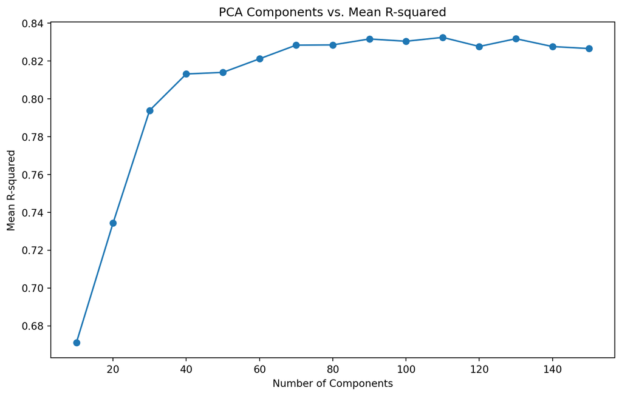

```python
plt.figure(figsize=(10, 6))
plt.plot(results_df["Number of Components"],
         results_df["Mean R-squared"], marker='o', linestyle='-')
plt.xlabel('Number of Components')
plt.ylabel('Mean R-squared')
plt.title('PCA Components vs. Mean R-squared')
plt.grid(False)
plt.show()
```

# 7 Hyperparameter Tuning

```python
n_components = 75

pca = PCA(n_components=n_components)
X_pca = pca.fit_transform(X_scaled)


# Split the data into training and testing sets
X_train, X_test, y_train, y_test = train_test_split(
    X_pca, y, test_size=0.2, random_state=42)

# Create an XGBoost Regressor model
xgb_model = XGBRegressor(random_state=42)

# Fit the model on the training data
xgb_model.fit(X_train, y_train)

# Predict on the test set
y_pred = xgb_model.predict(X_test)

# Evaluate the model using R-squared
r_squared = r2_score(y_test, y_pred)
# print("R-squared (single split):", r_squared)

# Perform 5-fold cross-validation
cv_scores = cross_val_score(xgb_model, X_pca, y, cv=5, scoring='r2')
# print("R-squared (cross-validation):", cv_scores)

# Calculate the average R-squared across all folds
mean_r_squared = np.mean(cv_scores)
print("Mean R-squared (cross-validation):", mean_r_squared)
```

```
Mean R-squared (cross-validation): 0.8310979590863281
```

- learning_rate: Learning rate determines the step size at each iteration during the gradient boosting process. A lower learning rate makes the model converge slower but may lead to better generalization, while a higher learning rate can make the model converge faster but could result in overfitting.
- n_estimators: The number of boosting rounds or trees in the ensemble. Increasing the number of estimators can improve the model’s performance until it starts to overfit. It’s a trade-off between model complexity and computational cost.
- max_depth: The maximum depth of each tree (estimator). It controls how deep the tree can grow during the boosting process. Deeper trees can capture more complex relationships in the data, but they can also lead to overfitting. Setting a reasonable max_depth is essential to avoid overfitting.

```python
# Define the hyperparameter space you want to search
param_grid = {
    'learning_rate': [0.01, 0.05, 0.1],
    'n_estimators': [100, 200, 300],
    'max_depth': [3, 5, 7],
    # Add more hyperparameters to the grid as needed
}

# Create an XGBoost Regressor model
xgb_model = XGBRegressor(random_state=42)

# Perform RandomizedSearchCV with 5-fold cross-validation
random_search = RandomizedSearchCV(
    xgb_model, param_distributions=param_grid, n_iter=10, cv=5, scoring='r2', random_state=42)
random_search.fit(X_pca, y)

# Print the best hyperparameters and best R-squared score
print("Best Hyperparameters:", random_search.best_params_)
print("Best R-squared:", random_search.best_score_)
```

```
Best Hyperparameters: {'n_estimators': 300, 'max_depth': 7, 'learning_rate': 0.05}
Best R-squared: 0.8453271541474052
```